# ChinmayRozekar_MachineLearning_Project2

Author : Chinmay Rozekar

## Problem Statement

### Context

AllLife Bank is a US bank that has a growing customer base. The majority of these customers are liability customers (depositors) with varying sizes of deposits. The number of customers who are also borrowers (asset customers) is quite small, and the bank is interested in expanding this base rapidly to bring in more loan business and in the process, earn more through the interest on loans. In particular, the management wants to explore ways of converting its liability customers to personal loan customers (while retaining them as depositors).

A campaign that the bank ran last year for liability customers showed a healthy conversion rate of over 9% success. This has encouraged the retail marketing department to devise campaigns with better target marketing to increase the success ratio.

You as a Data scientist at AllLife bank have to build a model that will help the marketing department to identify the potential customers who have a higher probability of purchasing the loan.

### Objective

To predict whether a liability customer will buy personal loans, to understand which customer attributes are most significant in driving purchases, and identify which segment of customers to target more.

### Data Dictionary

- `ID`: Customer ID
- `Age`: Customer’s age in completed years
- `Experience`: #years of professional experience
- `Income`: Annual income of the customer (in thousand dollars)
- `ZIP Code`: Home Address ZIP code.
- `Family`: the Family size of the customer
- `CCAvg`: Average spending on credit cards per month (in thousand dollars)
- `Education`: Education Level. 1: Undergrad; 2: Graduate;3: Advanced/Professional
- `Mortgage`: Value of house mortgage if any. (in thousand dollars)
- `Personal_Loan`: Did this customer accept the personal loan offered in the last campaign? (0: No, 1: Yes)
- `Securities_Account`: Does the customer have securities account with the bank? (0: No, 1: Yes)
- `CD_Account`: Does the customer have a certificate of deposit (CD) account with the bank? (0: No, 1: Yes)
- `Online`: Do customers use internet banking facilities? (0: No, 1: Yes)
- `CreditCard`: Does the customer use a credit card issued by any other Bank (excluding All life Bank)? (0: No, 1: Yes)

## Importing necessary libraries

```python
# Installing the libraries with the specified version.
!pip install numpy==1.25.2 pandas==1.5.3 matplotlib==3.7.1 seaborn==0.13.1 scikit-learn==1.2.2 sklearn-pandas==2.2.0 -q --user
```

**Note**:

1. After running the above cell, kindly restart the notebook kernel (for Jupyter Notebook) or runtime (for Google Colab), write the relevant code for the project from the next cell, and run all cells sequentially from the next cell.
2. On executing the above line of code, you might see a warning regarding package dependencies. This error message can be ignored as the above code ensures that all necessary libraries and their dependencies are maintained to successfully execute the code in this notebook.

```python
# Libraries to help with reading and manipulating data
import numpy as np
import pandas as pd

# Libraries to help with data visualization
import matplotlib.pyplot as plt
import seaborn as sns

sns.set()

# Removes the limit for the number of displayed columns
pd.set_option("display.max_columns", None)
# Sets the limit for the number of displayed rows
pd.set_option("display.max_rows", 200)

# to split the data into train and test
from sklearn.model_selection import train_test_split

# to build linear regression_model
from sklearn.linear_model import LinearRegression

# to check model performance
from sklearn.metrics import mean_absolute_error, mean_squared_error, r2_score

# To build model for prediction
from sklearn.tree import DecisionTreeClassifier
from sklearn import tree

# To get diferent metric scores
from sklearn.metrics import (
    f1_score,
    accuracy_score,
    recall_score,
    precision_score,
    confusion_matrix,
)

# to suppress warnings
import warnings

warnings.filterwarnings("ignore")
```

## Loading the dataset

```python
from google.colab import drive
drive.mount('/content/drive')
```

```python
df= pd.read_csv('/content/drive/MyDrive/PGP-AIML UT AUSTIN/Loan_Modelling.csv')
```

```python
data = df.copy()
```

Making copy of the data

## Data Overview

- Observations
- Sanity checks

```python
data.head()
```

|  | ID | Age | Experience | Income | ZIPCode | Family | CCAvg | Education | Mortgage | Personal_Loan | Securities_Account | CD_Account | Online | CreditCard |
| --- | --- | --- | --- | --- | --- | --- | --- | --- | --- | --- | --- | --- | --- | --- |
| 0 | 1 | 25 | 1 | 49 | 91107 | 4 | 1.6 | 1 | 0 | 0 | 1 | 0 | 0 | 0 |
| 1 | 2 | 45 | 19 | 34 | 90089 | 3 | 1.5 | 1 | 0 | 0 | 1 | 0 | 0 | 0 |
| 2 | 3 | 39 | 15 | 11 | 94720 | 1 | 1.0 | 1 | 0 | 0 | 0 | 0 | 0 | 0 |
| 3 | 4 | 35 | 9 | 100 | 94112 | 1 | 2.7 | 2 | 0 | 0 | 0 | 0 | 0 | 0 |
| 4 | 5 | 35 | 8 | 45 | 91330 | 4 | 1.0 | 2 | 0 | 0 | 0 | 0 | 0 | 1 |

```python
data.tail()
```

|  | ID | Age | Experience | Income | ZIPCode | Family | CCAvg | Education | Mortgage | Personal_Loan | Securities_Account | CD_Account | Online | CreditCard |
| --- | --- | --- | --- | --- | --- | --- | --- | --- | --- | --- | --- | --- | --- | --- |
| 4995 | 4996 | 29 | 3 | 40 | 92697 | 1 | 1.9 | 3 | 0 | 0 | 0 | 0 | 1 | 0 |
| 4996 | 4997 | 30 | 4 | 15 | 92037 | 4 | 0.4 | 1 | 85 | 0 | 0 | 0 | 1 | 0 |
| 4997 | 4998 | 63 | 39 | 24 | 93023 | 2 | 0.3 | 3 | 0 | 0 | 0 | 0 | 0 | 0 |
| 4998 | 4999 | 65 | 40 | 49 | 90034 | 3 | 0.5 | 2 | 0 | 0 | 0 | 0 | 1 | 0 |
| 4999 | 5000 | 28 | 4 | 83 | 92612 | 3 | 0.8 | 1 | 0 | 0 | 0 | 0 | 1 | 1 |

```python
data.shape
```

```
(5000, 14)
```

The dataset contains **5,000 rows** and **14 columns**.

```python
data.info()
```

```
<class 'pandas.core.frame.DataFrame'>
RangeIndex: 5000 entries, 0 to 4999
Data columns (total 14 columns):
 #   Column              Non-Null Count  Dtype
---  ------              --------------  -----
 0   ID                  5000 non-null   int64
 1   Age                 5000 non-null   int64
 2   Experience          5000 non-null   int64
 3   Income              5000 non-null   int64
 4   ZIPCode             5000 non-null   int64
 5   Family              5000 non-null   int64
 6   CCAvg               5000 non-null   float64
 7   Education           5000 non-null   int64
 8   Mortgage            5000 non-null   int64
 9   Personal_Loan       5000 non-null   int64
 10  Securities_Account  5000 non-null   int64
 11  CD_Account          5000 non-null   int64
 12  Online              5000 non-null   int64
 13  CreditCard          5000 non-null   int64
dtypes: float64(1), int64(13)
memory usage: 547.0 KB
```

The dataset consists of 5,000 entries (rows) and 14 columns (features).

All columns are complete with no missing values. Among them:

13 columns are of data type integer (int64), and

1 column, CCAvg, is of type float (float64).

```python
data.describe().T
```

|  | count | mean | std | min | 25% | 50% | 75% | max |
| --- | --- | --- | --- | --- | --- | --- | --- | --- |
| ID | 5000.0 | 2500.500000 | 1443.520003 | 1.0 | 1250.75 | 2500.5 | 3750.25 | 5000.0 |
| Age | 5000.0 | 45.338400 | 11.463166 | 23.0 | 35.00 | 45.0 | 55.00 | 67.0 |
| Experience | 5000.0 | 20.104600 | 11.467954 | -3.0 | 10.00 | 20.0 | 30.00 | 43.0 |
| Income | 5000.0 | 73.774200 | 46.033729 | 8.0 | 39.00 | 64.0 | 98.00 | 224.0 |
| ZIPCode | 5000.0 | 93169.257000 | 1759.455086 | 90005.0 | 91911.00 | 93437.0 | 94608.00 | 96651.0 |
| Family | 5000.0 | 2.396400 | 1.147663 | 1.0 | 1.00 | 2.0 | 3.00 | 4.0 |
| CCAvg | 5000.0 | 1.937938 | 1.747659 | 0.0 | 0.70 | 1.5 | 2.50 | 10.0 |
| Education | 5000.0 | 1.881000 | 0.839869 | 1.0 | 1.00 | 2.0 | 3.00 | 3.0 |
| Mortgage | 5000.0 | 56.498800 | 101.713802 | 0.0 | 0.00 | 0.0 | 101.00 | 635.0 |
| Personal_Loan | 5000.0 | 0.096000 | 0.294621 | 0.0 | 0.00 | 0.0 | 0.00 | 1.0 |
| Securities_Account | 5000.0 | 0.104400 | 0.305809 | 0.0 | 0.00 | 0.0 | 0.00 | 1.0 |
| CD_Account | 5000.0 | 0.060400 | 0.238250 | 0.0 | 0.00 | 0.0 | 0.00 | 1.0 |
| Online | 5000.0 | 0.596800 | 0.490589 | 0.0 | 0.00 | 1.0 | 1.00 | 1.0 |
| CreditCard | 5000.0 | 0.294000 | 0.455637 | 0.0 | 0.00 | 0.0 | 1.00 | 1.0 |

Here are the key observations from the descriptive statistics:

- The average customer is **45 years old**, with **20 years of experience**, although there are **some negative experience values**, indicating possible data issues.
- The **mean income** is approximately **$73.77K**, with a **maximum of $224K**, suggesting a wide income range and possible high-income outliers.
- **Credit card average spend (CCAvg)** has a median of **$1.5K/month**, but values go up to **$10K**, again showing a right-skewed distribution.
- **Mortgage values** are heavily skewed — **50% of customers have $0**, but the maximum reaches **$635K**, suggesting that many customers don’t have a mortgage, while a few have very large ones.
- The target variable `Personal_Loan` shows **only 9.6% of customers accepted a loan**, indicating a **class imbalance**.
- Binary features such as `Securities_Account`, `CD_Account`, and `CreditCard` also show **low means**, confirming that **most customers do not hold these accounts**.
- Education is encoded from 1 to 3, with a majority having **undergraduate or graduate-level education**.

```python
data.isnull().sum()
```

|  | 0 |
| --- | --- |
| ID | 0 |
| Age | 0 |
| Experience | 0 |
| Income | 0 |
| ZIPCode | 0 |
| Family | 0 |
| CCAvg | 0 |
| Education | 0 |
| Mortgage | 0 |
| Personal_Loan | 0 |
| Securities_Account | 0 |
| CD_Account | 0 |
| Online | 0 |
| CreditCard | 0 |

**dtype:** int64

No Null values

## Exploratory Data Analysis.

- EDA is an important part of any project involving data.
- It is important to investigate and understand the data better before building a model with it.
- A few questions have been mentioned below which will help you approach the analysis in the right manner and generate insights from the data.
- A thorough analysis of the data, in addition to the questions mentioned below, should be done.

**Questions**:

1. What is the distribution of mortgage attribute? Are there any noticeable patterns or outliers in the distribution?
2. How many customers have credit cards?
3. What are the attributes that have a strong correlation with the target attribute (personal loan)?
4. How does a customer's interest in purchasing a loan vary with their age?
5. How does a customer's interest in purchasing a loan vary with their education?

**Univariate Analysis**

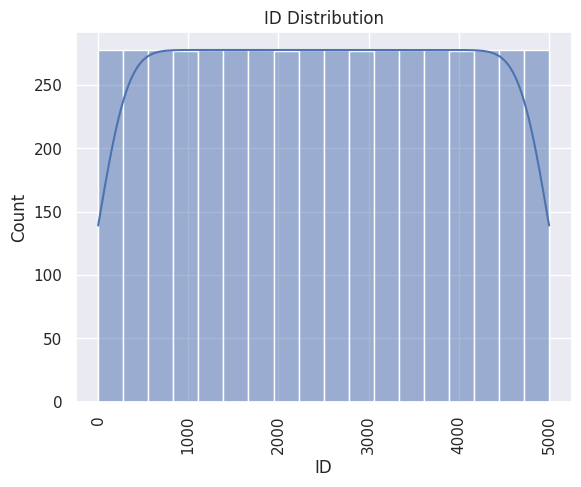

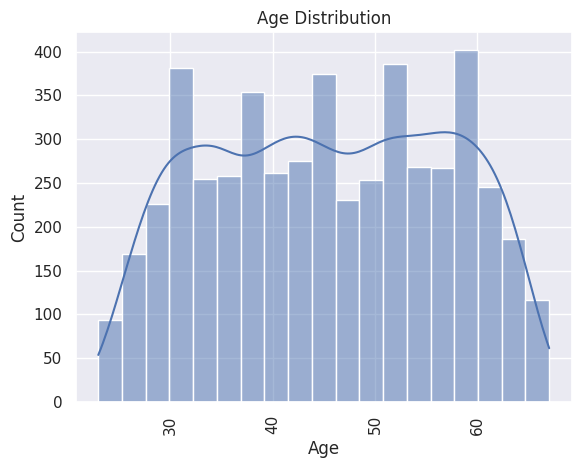

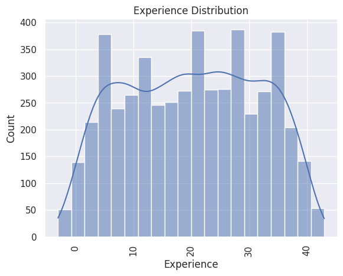

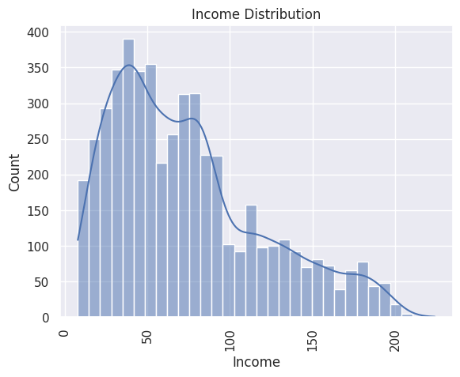

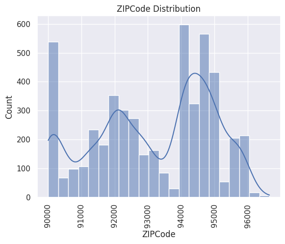

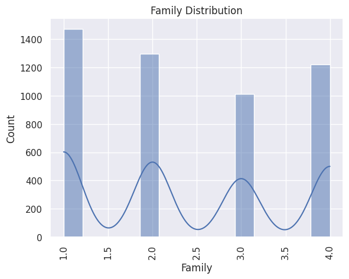

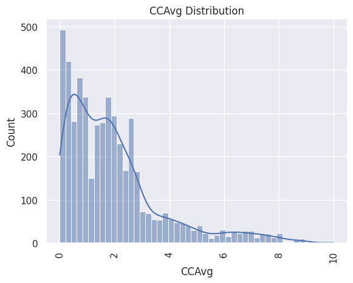

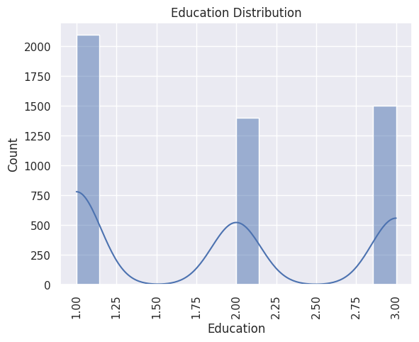

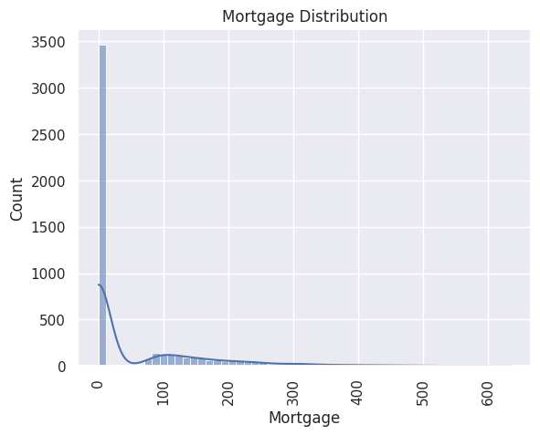

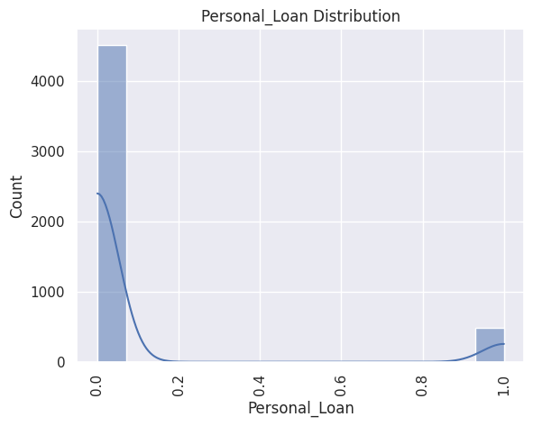

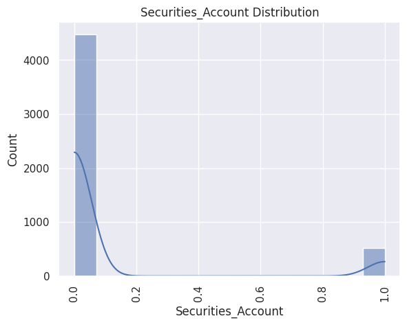

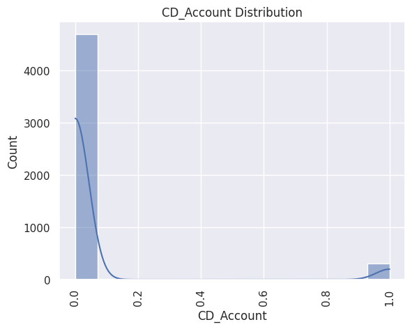

[2 more figures not shown]

```python
cols_num= data.select_dtypes(['float64','int64'])

for i in cols_num.columns:
    sns.histplot(data=data,x=i,kde=True)
    plt.title(f'{i} Distribution')
    plt.xticks(rotation=90)
    plt.show()
```

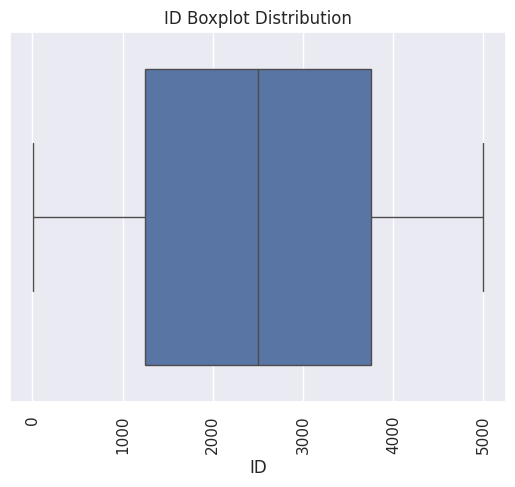

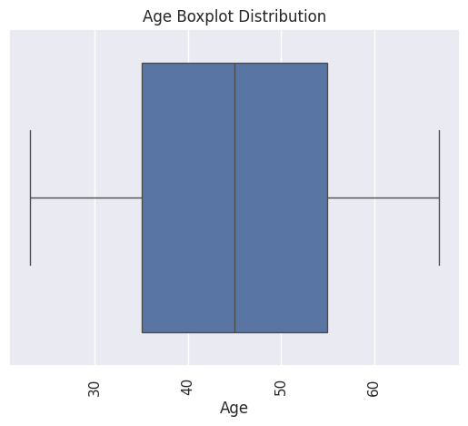

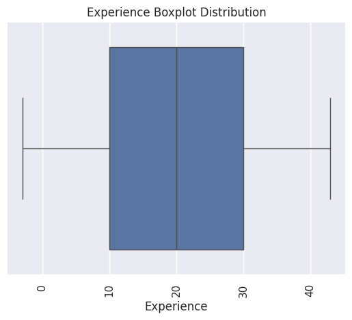

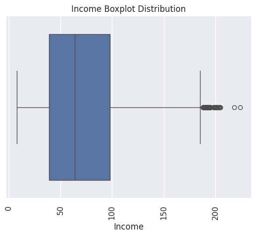

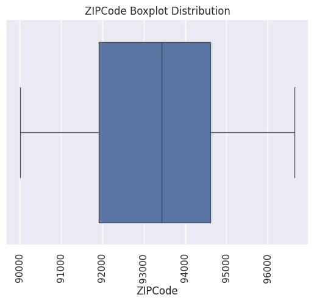

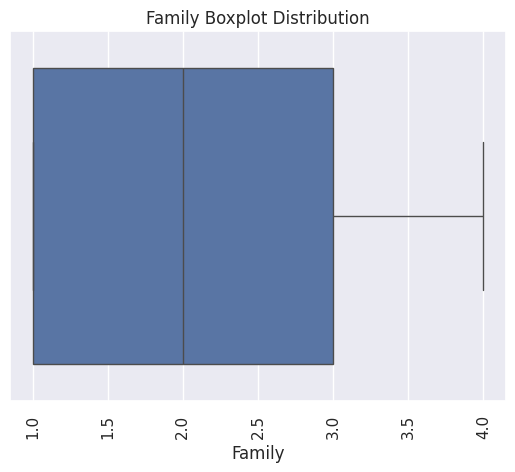

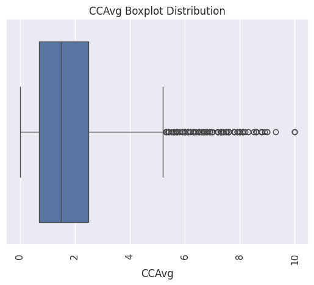

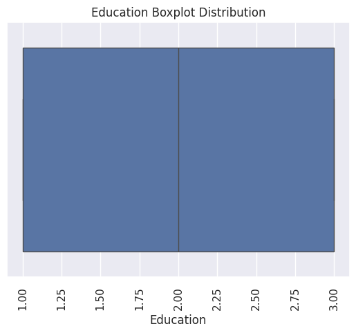

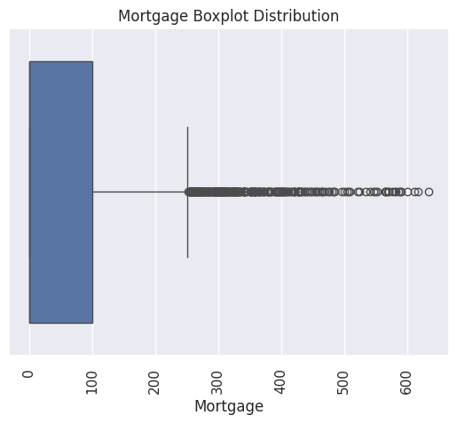

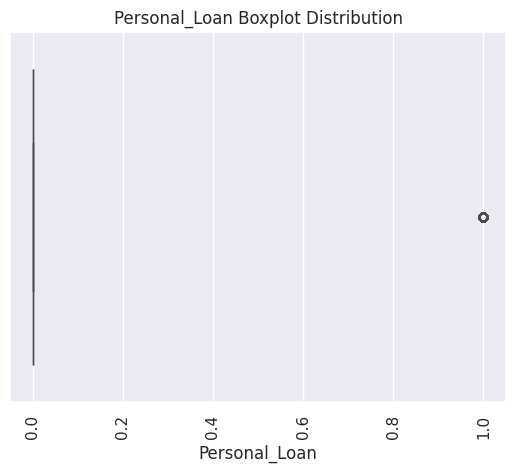

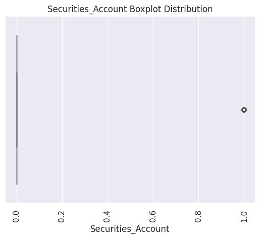

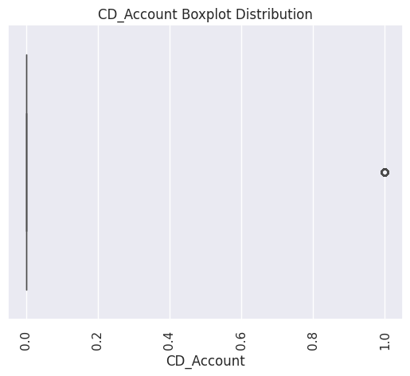

[2 more figures not shown]

```python
for i in cols_num.columns:
  sns.boxplot(data=data,x=i)
  plt.title(f'{i} Boxplot Distribution')
  plt.xticks(rotation=90)
  plt.show()
```

**Bivariate Analysis**

```
Count of 0 mortgage: 3462
Count of non-zero mortgage: 1538
```

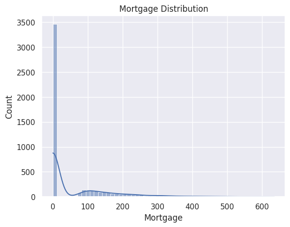

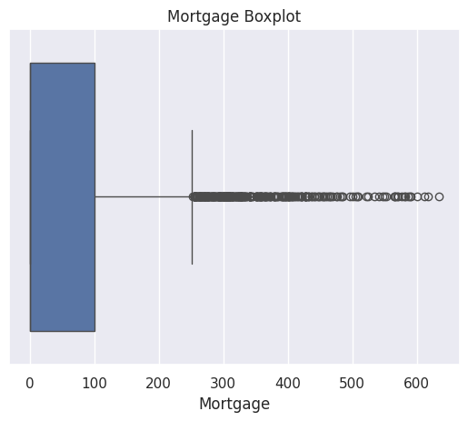

```python
# What is the distribution of mortgage attribute? Are there any noticeable patterns or outliers in the distribution?


# Count how many people have 0 mortgage
print("Count of 0 mortgage:", (data['Mortgage'] == 0).sum())
print("Count of non-zero mortgage:", (data['Mortgage'] != 0).sum())

# Plot histogram
sns.histplot(data['Mortgage'], kde=True)
plt.title('Mortgage Distribution')
plt.show()

# Plot boxplot
sns.boxplot(x=data['Mortgage'])
plt.title('Mortgage Boxplot')
plt.show()
```

This visualization shows that the Mortgage attribute is heavily concentrated at 0 with a long tail extending to high values, confirming the presence of right skewness and multiple outliers on the higher end.

```
1470
```

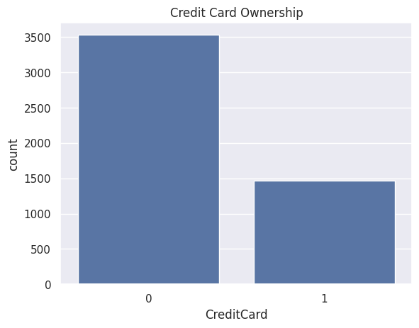

```python
credit_card_holders = data[data['CreditCard'] == 1]
print(credit_card_holders.shape[0])

sns.countplot(data=data,x='CreditCard')
plt.title('Credit Card Ownership')
plt.show()
```

1,470 customers in the dataset have credit cards.

```
Correlation with Personal_Loan:

Personal_Loan         1.000000
Income                0.502462
CCAvg                 0.366889
CD_Account            0.316355
Mortgage              0.142095
Education             0.136722
Family                0.061367
Securities_Account    0.021954
Online                0.006278
CreditCard            0.002802
ZIPCode              -0.002974
Experience           -0.007413
Age                  -0.007726
ID                   -0.024801
Name: Personal_Loan, dtype: float64
```

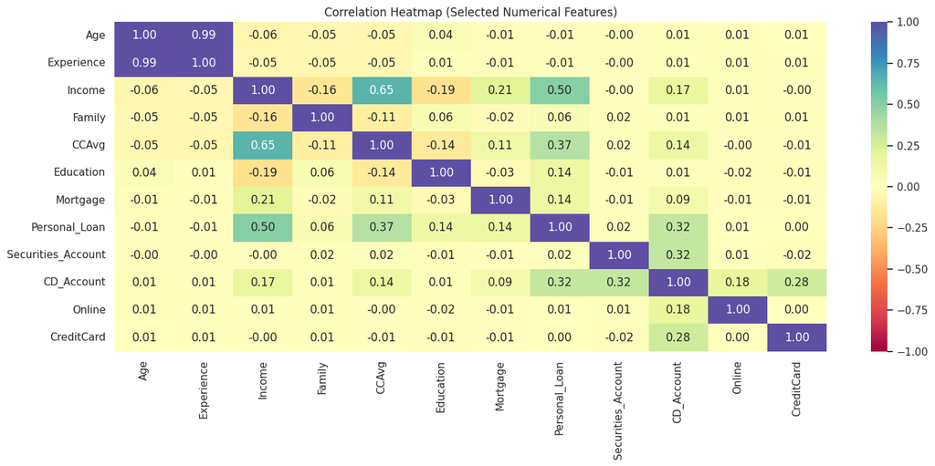

```python
# What are the attributes that have a strong correlation with the target attribute (personal loan)?


correlations = data.corr(numeric_only=True)['Personal_Loan'].sort_values(ascending=False)
print("Correlation with Personal_Loan:\n")
print(correlations)

# Get list of numeric columns
cols_list = data.select_dtypes(include=np.number).columns.tolist()

# Remove non-informative columns
cols_list.remove("ID")        # ID is just an identifier
cols_list.remove("ZIPCode")   # ZIP code may not be useful for correlation

# Plot the heatmap for selected numerical features
plt.figure(figsize=(15, 7))
sns.heatmap(data[cols_list].corr(), annot=True, vmin=-1, vmax=1, fmt=".2f", cmap="Spectral")
plt.title("Correlation Heatmap (Selected Numerical Features)")
plt.tight_layout()
plt.show()
```

- Income, CCAvg, and CD_Account show the strongest positive correlation with Personal_Loan, indicating they are key factors influencing loan acceptance.
- Other features like Age, Experience, and ZIPCode have little to no correlation, making them less relevant for predicting loan decisions.

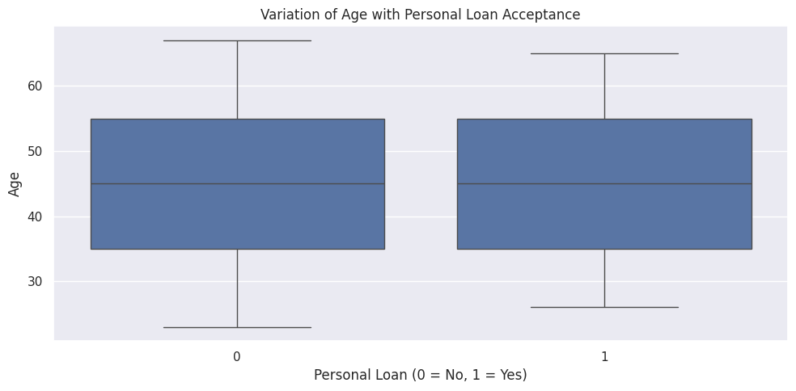

```python
# How does a customer's interest in purchasing a loan vary with their age?

plt.figure(figsize=(10, 5))
sns.boxplot(x=data['Personal_Loan'], y=data['Age'])
plt.title("Variation of Age with Personal Loan Acceptance")
plt.xlabel("Personal Loan (0 = No, 1 = Yes)")
plt.ylabel("Age")
plt.tight_layout()
plt.show()
```

However,the overall age ranges overlap significantly, indicating that age alone is not a strong predictor of loan acceptance.

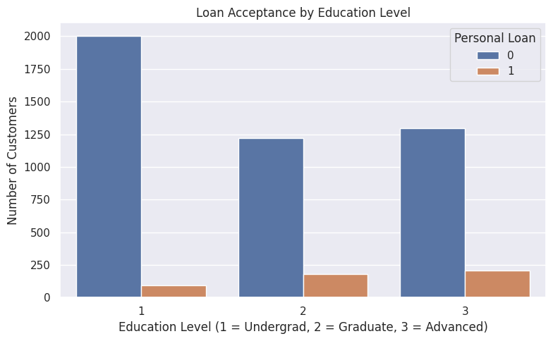

```python
# How does a customer's interest in purchasing a loan vary with their education?

plt.figure(figsize=(8, 5))
sns.countplot(x='Education', hue='Personal_Loan', data=data)
plt.title('Loan Acceptance by Education Level')
plt.xlabel('Education Level (1 = Undergrad, 2 = Graduate, 3 = Advanced)')
plt.ylabel('Number of Customers')
plt.legend(title='Personal Loan')
plt.tight_layout()
plt.show()
```

- Customers with higher education levels (Graduate and Advanced) are more likely to accept personal loans compared to those with only undergraduate education.
- The lowest loan acceptance is observed among customers with undergraduate education (Level 1).

## Data Preprocessing

- Missing value treatment
- Feature engineering (if needed)
- Outlier detection and treatment (if needed)
- Preparing data for modeling
- Any other preprocessing steps (if needed)

```python
# Missing value treatment

data.isnull().sum()
```

|  | 0 |
| --- | --- |
| ID | 0 |
| Age | 0 |
| Experience | 0 |
| Income | 0 |
| ZIPCode | 0 |
| Family | 0 |
| CCAvg | 0 |
| Education | 0 |
| Mortgage | 0 |
| Personal_Loan | 0 |
| Securities_Account | 0 |
| CD_Account | 0 |
| Online | 0 |
| CreditCard | 0 |

**dtype:** int64

No missing values

```python
# Feature engineering (if needed)

data.drop('ID',axis=1,inplace=True)
```

ID is just an identifier. Hence droped

**Outlier detection and treatment (if needed)**

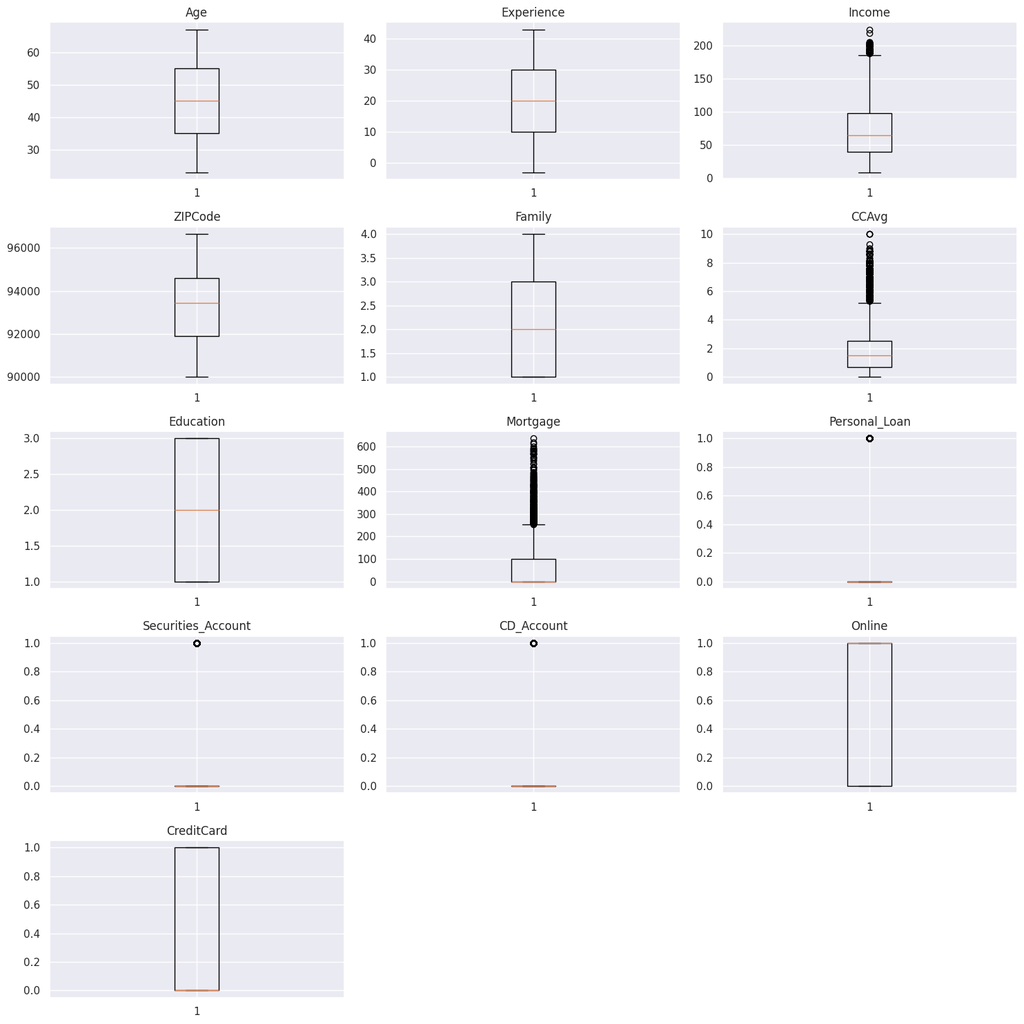

```python
# Get numeric columns
cols_list = data.select_dtypes(include='number').columns.tolist()
cols_list

numeric_columns = ['Age','Experience','Income','ZIPCode','Family','CCAvg','Education','Mortgage','Personal_Loan','Securities_Account','CD_Account','Online','CreditCard']

plt.figure(figsize=(15,15))

for i, variable in enumerate(numeric_columns):
    plt.subplot(5, 3, i + 1)
    plt.boxplot(data[variable], whis=1.5)
    plt.tight_layout()
    plt.title(variable)

plt.show()
```

```python
# to find the 25th percentile and 75th percentile for the numerical columns.

Q1 = data[numeric_columns].quantile(0.25)
Q3 = data[numeric_columns].quantile(0.75)

IQR = Q3 - Q1                   #Inter Quantile Range (75th percentile - 25th percentile)

lower_whisker = Q1 - 1.5*IQR    #Finding lower and upper bounds for all values. All values outside these bounds are outliers
upper_whisker = Q3 + 1.5*IQR
```

```python
# Identifying outliers

# Percentage of outliers in each column
((data[numeric_columns] < lower_whisker) | (data[numeric_columns] > upper_whisker)).sum()/data.shape[0]*100
```

|  | 0 |
| --- | --- |
| Age | 0.00 |
| Experience | 0.00 |
| Income | 1.92 |
| ZIPCode | 0.00 |
| Family | 0.00 |
| CCAvg | 6.48 |
| Education | 0.00 |
| Mortgage | 5.82 |
| Personal_Loan | 9.60 |
| Securities_Account | 10.44 |
| CD_Account | 6.04 |
| Online | 0.00 |
| CreditCard | 0.00 |

**dtype:** float64

- The highest outlier percentages are in Securities_Account (10.44%), Personal_Loan (9.60%), and CCAvg (6.48%), indicating some deviation from typical values.
- Columns like Age, Experience, ZIPCode, Family, Education, Online, and CreditCard show no outliers using the IQR method.
- Since the outliers are relatively few and may represent valid extreme customer behaviors, it's okay to keep them

**Data Preparation for Modeling**

```python
# dropping Experience as it is perfectly correlated with Age
X = data.drop(["Personal_Loan", "Experience"], axis=1)
y = data["Personal_Loan"]

X = pd.get_dummies(X, columns=["ZIPCode", "Education"], drop_first=True)

X = X.astype(float)

# Splitting data in train and test sets
X_train, X_test, y_train, y_test = train_test_split(
    X, y, test_size=0.30, random_state=1
)
```

```python
print("Shape of Training set : ", X_train.shape)
print("Shape of test set : ", X_test.shape)
print("Percentage of classes in training set:")
print(y_train.value_counts(normalize=True))
print("Percentage of classes in test set:")
print(y_test.value_counts(normalize=True))
```

```
Shape of Training set :  (3500, 477)
Shape of test set :  (1500, 477)
Percentage of classes in training set:
Personal_Loan
0    0.905429
1    0.094571
Name: proportion, dtype: float64
Percentage of classes in test set:
Personal_Loan
0    0.900667
1    0.099333
Name: proportion, dtype: float64
```

We observed that around 90.5% of the observations belong to class 0 (Did not accept loan) and 9.5% belong to class 1 (Accepted loan). This class imbalance is preserved in both the training and test sets, ensuring consistency for model evaluation.